# Exploratory Analysis of Conflict Data

### Discuss the distribution(s) of your variable(s) of interest. Were there any unusual points? Did you need to perform any transformations?

> The dataset captured three types of conflicts, state-based, non-state based and one-sided violence. State-based data dated from 1946-2017 while non-state and one-sided violence conflicts were observed from 1989 to 2017. In comparing the three conflicts I restricted the years to 1989-2017 to allow for a fair comparison of frequency across the three conflict types. However, for a deeper dive into exclusively state=based conflicts I expanded the date range to start at 1946 (the first recorded entry of state-based conflicts in the dataset).

### Of the features you investigated, were there any unusual distributions? Did you perform any operations on the data to tidy, adjust, or change the form of the data? If so, why did you do this?

> The final dataset is an combination of three major datasets. To merge the three datasets into one dataset I had to tidy and merge the three data sets into one. This involved renaming columns to align data frames columns for concatenation, impute missing values and decoding categorical variables that had been coded with numbers.

## Bivariate Exploration

> I will begin by exploring the effects of rebel strenght and its proxies on conflict outcomes.

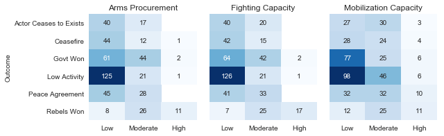

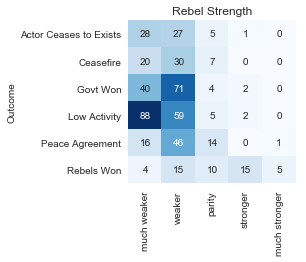

```python
reb_strengths=[nsa_reb_strength,nsa_reb_mobcap,nsa_reb_armsproc,nsa_reb_fightcap]
updated_reb_strengths=pd.DataFrame(columns=['outcome','new_dyadid_18','variable','value'])
for df in reb_strengths:
    df=pd.melt(df, id_vars=['outcome','new_dyadid_18'], value_vars=df.columns[0])
    updated_reb_strengths=pd.concat([updated_reb_strengths,df])

reb_strengths_outcome=updated_reb_strengths.groupby(['variable','outcome','value']).size().reset_index(name='count')
reb_strengths_outcome_hm=reb_strengths_outcome.query('outcome!="--"')


def draw_heatmap(*args, **kwargs):
    data = kwargs.pop('data')
    d = data.pivot(index=args[1], columns=args[0], values=args[2])[['low','moderate','high']]
    sb.heatmap(d, xticklabels=True, yticklabels=True,annot = True, cmap = "Blues" ,fmt='g',**kwargs)


g = sb.FacetGrid(data = reb_strengths_outcome_hm.query('variable!="rebstrength"'), col = 'variable')
g.map_dataframe(draw_heatmap,'value','outcome',  'count', cbar=False)


titles=['Arms Procurement','Fighting Capacity','Mobilization Capacity']
for ax,title in zip(g.axes.flat,titles):
    # set aspect of all axis
    ax.set(title=title, xlabel='',ylabel='')
    ax.set_xticklabels(['Low','Moderate','High']
                      )
g.axes.flat[0].set(ylabel='Outcome')
plt.show()


fig,ax=plt.subplots(figsize=(3,3))
sb.heatmap(data=reb_strengths_outcome_hm.query('variable=="rebstrength"').pivot_table(index='outcome',columns='value',values='count').fillna(0)[['much weaker','weaker','parity','stronger','much stronger']],annot = True, cmap = "Blues" ,fmt='g', cbar=False);
ax.set(title='Rebel Strength',ylabel='Outcome',xlabel='');
```

**Effect of Rebel Strength on the Outcome of Intrastate Dyads:**

> - Surprisingly, when the strength of a rebel group is *much weaker* than the government or its ability to procure arms, fighting capacity and mobilization capacity is lower than the government, the most common outcome is *Low Activity* across each of the four variables. Low activity refers to conflicts that continue but do not reach the 25 battle related deaths per year threshold set by the UCDP. There is no information in this dataset regarding the specific circumstance that led to a Low Activity outcome or why the Government did not win. According to the UCDP Conflict Termination codebook possible reasons for Low Activity may be because of successful military operations by the counterpart (i.e. victory), but it could also be for a strategic reorientation towards the use of nonviolent or nonfatal methods, to explore the possibility of negotiations, organizational reorganization, or intra-rebel fighting. Indeed, it may often be a combination of these factors.
> - When the strength of a rebel group is *weaker* the most common outcome is a victory for the government.  
>   When the strength of a rebel group is *at par* with the government the most common outcome is a Peace Agreement
> - Finally, when the rebel group is stronger than the government is a victory for the rebels.

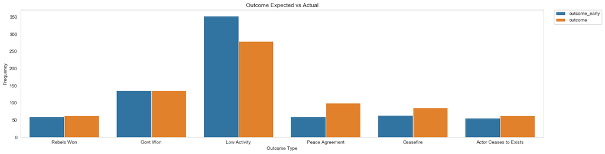

```python
#outcome early vs outcome dyad year

outcomes=conflict_df_copy[['new_dyadid_18','outcome_early','outcome']].melt(id_vars=['new_dyadid_18'])
fig,ax=plt.subplots(figsize=(20,5))
sb.countplot(data = outcomes.query('value!="--"'), x = 'value', hue = 'variable')
ax.set(xlabel='Outcome Type',ylabel='Frequency',title='Outcome Expected vs Actual')
plt.legend(bbox_to_anchor=(1.02, 1), loc=2, borderaxespad=0.);
```

**Effect of Rebel Strength on the Outcome of Intrastate Dyads:**

> - The window during which an intrastate armed conflict no longer meets threshold qualified by the UCDP ranges from the final year of activity and first year of non-activity. Comparing the results of the Outcome expected given the resolution in the final year of activity and the actual outcome manifested in the first year of non activity the general trend indicates that outcomes end towards peaceful resolutions namely peace agreements and ceasefires more often than initially expected.